# Central LPHA Region Report

11/18/2021

**Prepared by the Colorado COVID-19 Modeling Group**  
Colorado School of Public Health: Andrea Buchwald, Elizabeth Carlton, Debashis Ghosh, Irina Kasarskis, Jonathan Samet, Emily Wu; University of Colorado School of Medicine: Kathryn Colborn; University of Colorado-Boulder Department of Applied Mathematics: Sabina Altus, David Bortz; Colorado State University: Jude Bayham

For Contact: Jon.Samet@CUAnschutz.edu

Effective reproductive number (Re) reflects hospitalization data through 11/08/2021. In regions with smaller populations, reported cases are also used to generate these estimates. The prevalence of infections and percent of the population infected is estimated for 11/01/2021. Due to lags between infection and hospitalization, estimates of transmission control and the effective reproductive number represent the spread of infections through approximately 10/26/2021.

The Central LPHA region includes Chaffee, El Paso, Lake, Park and Teller counties.

| Central Region Are infections increasing or decreasing? Re | Central Region Are infections increasing or decreasing? Infections are… | Central Region How many people are infectious? Prevalence per 100,000 | Central Region How many people are infectious? People infectious | Central Region Percent of Population Estimated Immune |
| --- | --- | --- | --- | --- |
| 0.7 | Decreasing | 1,317 | 1 in 76 | 55.5 |

Table 1. Due to lags between infection and hospitalization, the estimated effective reproductive number (Re) reflects the spread of infections approximately two weeks prior to the data of the last observed hospitalization.

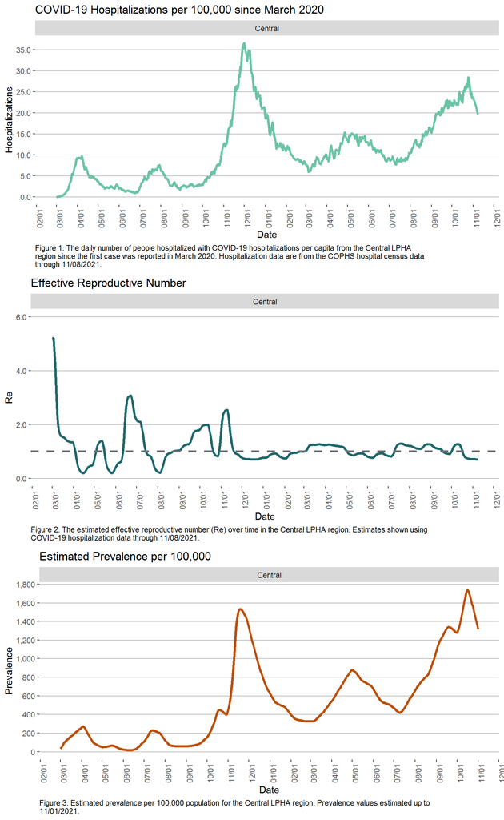

| Central Region County | Central Region Daily Average Number of Cases in the past 7 days per 100,000 population |
| --- | --- |
| Chaffee | 60.8 |
| El Paso | 58.2 |
| Lake | 21.7 |
| Park | 33.0 |
| Teller | 50.1 |

Table 2. Case counts are from the [NY Times](https://github.com/nytimes/covid-19-data) and reflect cases reported to CDPHE from 11/02/2021 - 11/08/2021. Cases are grouped based on the date they are reported. Population data are 2020 estimates from the [Colorado Demography Office](https://demography.dola.colorado.gov/population/data/sya-county/). These estimates may not represent the full number of COVID-19 cases diagnosed in Colorado during this time period.